# Chapter 02 - Probability

## 2. Probability

### 2.2 Sample Spaces and Events

The **sample space** $\Omega$ is the set of possible outcomes of an experiment. Points $\omega$ in $\Omega$ are called **sample outcomes** or **realizations**. **Events** are subsets of $\Omega$.

Given an event $A$, let $A^c = \{ \omega \in \Omega : \text{not } (\omega \in A) \}$ denote the complement of $A$. The complement of $\Omega$ is the empty set $\varnothing$. The union of events $A$ and $B$ is defined as $A \cup B = \{ \omega \in \Omega : \omega \in A \text{ or } \omega \in B \}$. If $A_1, A_2, \dots$ is a sequence of sets, then

$$ \cup_{i=1}^\infty A_i = \left\{ \omega \in \Omega : \omega \in A_i \text{ for some } i \right\}$$

The intersection of $A$ and $B$ is $A \cap B = \{ \omega \in \Omega : \omega \in A \text{ and } \omega \in B \}$. If $A_1, A_2, \dots$ is a sequence of sets then

$$ \cap_{i=1}^\infty A_i = \left\{ \omega \in \Omega : \omega \in A_i \text{ for all } i \right\}$$

Let $A - B = \left\{ \omega \in \Omega : \omega \in A \text{ and not } (\omega \in B) \right\}$. If every element of $A$ is contained in $B$ we write $A \subset B$ or $B \supset A$. If $A$ is a finite set, let $|A|$ denote the number of elements in $A$.

| notation | meaning |
| --- | --- |
| $\Omega$ | sample space |
| $\omega$ | outcome |
| $A$ | event (subset of $\Omega$) |
| $\vert A \vert$ | number of elements in $A$ (if finite) |
| $A^c$ | complement of $A$ (not $A$) |
| $A \cup B$ | union ($A$ or $B$) |
| $A \cap B$ or $AB$ | intersection ($A$ and $B$) |
| $A - B$ | set difference (points in $A$ but not in $B$) |
| $A \subset B$ | set inclusion ($A$ is a subset of or equal to $B$) |
| $\varnothing$ | null event (always false) |
| $\Omega$ | true event (always true) |

We say that $A_1, A_2, \dots$ are **disjoint** or **mutually exclusive** if $A_i \cap A_j = \varnothing$ whenever $i \neq j$. A **partition** of $\Omega$ is a sequence of disjoint sets $A_1, A_2, \dots$ such that $\cup_{i=1}^\infty A_i = \Omega$. Given an event $A$, define the **indicator function of $A$** by

$$ I_A(\omega) = I(\omega \in A) = \begin{cases} 1 &\text{if } \omega \in A \\ 0 &\text{otherwise} \end{cases}$$

A sequence of sets $A_1, A_2, \dots$ is **monotone increasing** if $A_1 \subset A_2 \subset \dots$, and we define $\lim_{n \rightarrow \infty} A_n = \cup_{i=1}^\infty A_i$. A sequence of sets $A_1, A_2, \dots$ is **monotone decreasing** if $A_1 \supset A_2 \supset \dots$ and then we define $\lim_{n \rightarrow \infty} A_n = \cap_{i=1}^n A_i$. In either case, we will write $A_n \rightarrow A$.

### 2.3 Probability

A function $\mathbb{P}$ that assign a real number $\mathbb{P}(A)$ to each event $A$ is a **probability distribution** or a **probability measure** if it satisfies the following three axioms:

- **Axiom 1**: $\mathbb{P}(A) \geq 0$ for every $A$
- **Axiom 2**: $\mathbb{P}(\Omega) = 1$
- **Axiom 3**: If $A_1, A_2, \dots$ are disjoint then

$$ \mathbb{P} \left( \cup_{i=1}^\infty A_i \right) = \sum_{i=1}^\infty \mathbb{P}(A_i) $$

A few properties that can be derived from the axioms:

- $\mathbb{P}(\varnothing) = 0$
- $A \subset B \Rightarrow \mathbb{P}(A) \leq \mathbb{P}(B)$
- $0 \leq \mathbb{P}(A) \leq 1$
- $\mathbb{P}\left(A^c\right) = 1 - \mathbb{P}(A)$
- $A \cap B = \varnothing \Rightarrow \mathbb{P}(A \cup B) = \mathbb{P}(A) + \mathbb{P}(B)$

**Lemma 2.6**. For any events $A$ and $B$, $\mathbb{P}(A \cup B) = \mathbb{P}(A) + \mathbb(B) - \mathbb{P}(AB)$.

**Proof**.

$$ \begin{align} \mathbb{P}(A \cup B) &= \mathbb{P}\left( (AB^c) \cup (AB) \cup (A^cB) \right) \\ &= \mathbb{P}(AB^c) + \mathbb{P}(AB) + \mathbb{P}(A^cB) \\ &= \mathbb{P}(AB^c) + \mathbb{P}(AB) + \mathbb{P}(A^cB) + \mathbb{P}(AB) - \mathbb{P}(AB) \\ &= \mathbb{P}((AB^c) \cup (AB)) + \mathbb{P}((A^cB) \cup (AB)) - \mathbb{P}(AB) \\ &= \mathbb{P}(A) + \mathbb{P}(B) - \mathbb{P}(AB) \end{align} $$

**Theorem 2.8 (Continuity of Probabilities)**. If $A_n \rightarrow A$ then $\mathbb{P}(A_n) \rightarrow \mathbb{P}(A)$ as $n \rightarrow \infty$.

**Proof**. Suppose that $A_n$ is monotone increasing, $A_1 \subset A_2 \subset \dots$. Let $B_1 = A_1$, and $B_{n+1} = A_{n+1} - A_n$ for $n > 1$. The $B_i$'s are disjoint by construction, and $A_n = \cup_{i=1}^n A_i = \cup_{i=1}^n B_i$ for all $n$. From axiom 3,

$$ \mathbb{P}(A_n) = \mathbb{P}\left( \cup_{i=1}^n B_i \right) = \sum_{i=1}^n \mathbb{P}(B_i) $$

and so

$$ \lim_{n \rightarrow \infty} \mathbb{P}(A_n) = \lim_{n \rightarrow \infty} \sum_{i=1}^n \mathbb{P}(B_n) = \sum_{i=1}^\infty \mathbb{P}(B_n) = \mathbb{P}\left( \cup_{i=1}^\infty B_i \right) = \mathbb{P}(A) $$

### 2.4 Probability on Finite Sample Spaces

If $\Omega$ is finite and each outcome is equally likely, then

$$ \mathbb{P}(A) = \frac{|A|}{|\Omega|} $$

which is called the **uniform probability distribution**.

We will need a few facts from counting theory later.

- Given $n$ objects, the number of way or ordering these objects is $n! = n \cdot (n - 1) \cdot (n - 2) \cdots 3 \cdot 2 \cdot 1$. We define $0! = 1$.
- We define

  $$ \binom{n}{k} = \frac{n!}{k! (n - k)!} $$

  read "n choose k", which is the number of different ways of choosing $k$ objects from $n$.
- Note that choosing a subset $k$ objects can be mapped to choosing the complement set of $n - k$ objects, so

  $$ \binom{n}{k} = \binom{n}{n - k} $$

  and that there is only one way of choosing the empty set, so

  $$ \binom{n}{0} = \binom{n}{n} = 1$$

### 2.5 Independent Events

- Two events $A$ and $B$ are **independent** if

  $$ \mathbb{P}(AB) = \mathbb{P}(A) \mathbb{P}(B) $$

  and we write $A \text{ ⫫ } B$. A set of events $\{ A_i : i \in I \}$ is independent if

  $$ \mathbb{P} \left( \cap_{i \in J} A_i \right) = \prod_{i \in J} \mathbb{P}(A_i) $$

  for every finite subset $J$ of $I$.
- Independence is sometimes assumed and sometimes derived.
- Disjoint events with positive probability are not independent.

### 2.6 Conditional Probability

- If $\mathbb{P}(B) > 0$ then the **conditional probability** of $A$ given $B$ is

  $$ \mathbb{P}(A | B) = \frac{\mathbb{P}(AB)}{\mathbb{P}(B)} $$
- $\mathbb{P}(\cdot | B)$ satisfies the axioms of probability, for fixed $B$. In general, $\mathbb{P}(A | \cdot)$ does **not** satisfies the axioms of probability for fixed $A$.
- In general, $\mathbb{P}(B | A) \neq \mathbb{P}(A | B)$.
- $A$ and $B$ are independent if and only if $\mathbb{P}(A | B) = \mathbb{P}(A)$.

### 2.7 Bayes' Theorem

**Theorem 2.15 (The Law of Total Probability)**. Let $A_1, \dots, A_k$ be a partition of $\Omega$. Then, for any event $B$,

$$ \mathbb{P}(B) = \sum_{i=1}^k \mathbb{P}(B | A_i) \mathbb{P}(A_i) $$

**Proof**. Let $C_j = BA_j$. Note that the $C_j$'s are disjoint and that $B = \cup_{i=1}^k C_j$. Hence

$$ \mathbb{P}(B) = \sum_j \mathbb{P}(C_j) = \sum_j \mathbb{P}(BA_j) = \sum_j \mathbb{P}(B | A_j) \mathbb{P}(A_j) $$

**Theorem 2.16 (Bayes' Theorem)**. Let $A_1, \dots, A_k$ be a partition of $\Omega$ such that $\mathbb{P}(A_i) > 0$ for each $i$. If $\mathbb{P}(B) > 0$, then, for each $i = 1, \dots, k$,

$$ \mathbb{P}(A_i | B) = \frac{\mathbb{P}(B | A_i) \mathbb{P}(A_i)}{\sum_j \mathbb{P}(B | A_j) \mathbb{P}(A_j)} $$

We call $\mathbb{P}(A_i)$ the **prior probability** of $A_i$ and $\mathbb{P}(A_i | B)$ the **posterior probability** of $A_i$.

**Proof**. We apply the definition of conditional probability twice, followed by the law of total probability:

$$ \mathbb{P}(A_i | B) = \frac{\mathbb{P}(A_i B) }{\mathbb{P}(B)} = \frac{\mathbb{P}(B | A_i) \mathbb{P}(A_i)}{\mathbb{P}(B)} = \frac{\mathbb{P}(B | A_i) \mathbb{P}(A_i)}{\sum_j \mathbb{P}(B | A_j) \mathbb{P}(A_j)}$$

### 2.9 Technical Appendix

Generally, it is not feasible to assign probabilities to all the subsets of a sample space $\Omega$. Instead, one restricts attention to a set of events called a **$\sigma$-algebra** or a **$\sigma$-field**, which is a class $\mathcal{A}$ that satisfies:

- $\varnothing \in \mathcal{A}$
- If $A_1, A_2, \dots \in \mathcal{A}$, then $\cup_{i=1}^\infty A_i \in \mathcal{A}$
- $A \in \mathcal{A}$ implies that $A^c \in \mathcal{A}$

The sets in $\mathcal{A}$ are said to be **measurable**. We call $(\Omega, \mathcal{A})$ a **measurable space**. If $\mathbb{P}$ is a probability measure defined in $\mathcal{A}$ then $(\Omega, \mathcal{A}, \mathbb{P})$ is a **probability space**. When $\Omega$ is the real line, we take $\mathcal{A}$ to be the smallest $\sigma$-field that contains all off the open sets, which is called the **Borel $\sigma$-field**.

### 2.10 Exercises

**Exercise 2.10.1**. Fill in the details in the proof of Theorem 2.8. Also, prove the monotone decreasing case.

If $A_n \rightarrow A$ then $\mathbb{P}(A_n) \rightarrow \mathbb{P}(A)$ as $n \rightarrow \infty$.

**Solution**.

Suppose that $A_n$ is monotone increasing, $A_1 \subset A_2 \subset \dots$. Let $B_1 = A_1$, and $B_{i+1} = A_{i+1} - A_i$ for $i > 1$.

The $B_i$'s are disjoint by construction: assuming without loss of generality $i < j$, $\omega \in B_i \cap B_j$ implies that $\omega$ is in $A_j$, $A_i$, but not in $A_{j - 1}$, $A_{i - 1}$, where $A_0 = \varnothing$. In particular, this means that $\omega \in A_{i}$ but not $\omega \in A_{j - 1}$. Since $A_i \subset A_{j - 1}$, this implies that no such $\omega$ can satisfy those properties, and so $B_i$ and $B_j$ are disjoint.

Note that $A_n = \cup_{i=1}^n A_i = \cup_{i=1}^n B_i$ for all $n$:

$$ \cup_{i=1}^n B_i = \cup_{i=1}^n (A_i - A_{i - 1}) \subset \cup_{i=1}^n A_i = A_n $$

Also note that $A_n \subset \cup_{i=1}^n B_i$, since, if $f(\omega) = \min \{ k : \omega \in A_k \}$, then $\omega \in B_{f(\omega)}$, so all elements of $A_n$ are in some $B_k$.

The proof follows as given; from axiom 3,

$$ \mathbb{P}(A_n) = \mathbb{P}\left( \cup_{i=1}^n B_i \right) = \sum_{i=1}^n \mathbb{P}(B_i) $$

and so

$$ \lim_{n \rightarrow \infty} \mathbb{P}(A_n) = \lim_{n \rightarrow \infty} \sum_{i=1}^n \mathbb{P}(B_n) = \sum_{i=1}^\infty \mathbb{P}(B_n) = \mathbb{P}\left( \cup_{i=1}^\infty B_i \right) = \mathbb{P}(A) $$

The monotone decreasing case can be obtained by looking at the complementary series $A_1^c, A_2^c, \dots$,which is monotone increasing. We get

$$ \begin{align} \lim_{n \rightarrow \infty} \mathbb{P}(A_n^c) &= \mathbb{P}(A^c) \\ \lim_{n \rightarrow \infty} 1 - \mathbb{P}(A_n^c) &= 1 - \mathbb{P}(A^c) \\ \lim_{n \rightarrow \infty} \mathbb{P}(A_n) &= 1 - \mathbb{P}(A) \end{align} $$

**Exercise 2.10.2**. Prove the statements in equation (2.1).

- $\mathbb{P}(\varnothing) = 0$
- $A \subset B \Rightarrow \mathbb{P}(A) \leq \mathbb{P}(B)$
- $0 \leq \mathbb{P}(A) \leq 1$
- $\mathbb{P}\left(A^c\right) = 1 - \mathbb{P}(A)$
- $A \cap B = \varnothing \Rightarrow \mathbb{P}(A \cup B) = \mathbb{P}(A) + \mathbb{P}(B)$

**Solution**.

- By partitioning the event space $\Omega$ into disjoint partitions $(\Omega, \varnothing)$ we get

  $$ \mathbb{P}(\Omega) + \mathbb{P}(\varnothing) = \mathbb{P}(\Omega) \Rightarrow \mathbb{P}(\varnothing) = 0 $$
- Assuming $A \subset B$ and partitioning $B$ as $(A, B - A)$, we get

  $$ \mathbb{P}(A) + \mathbb{P}(B - A) = \mathbb{P}(B) \Rightarrow \mathbb{P}(A) \leq \mathbb{P}(B) $$
- $\mathbb{P}(A) \geq 0$ from axiom 1. By partitioning $\Omega$ as $(A, A^c)$, we get

  $$ \mathbb{P}(A) + \mathbb{P}(A^c) = \mathbb{P}(\Omega) = 1 \Rightarrow \mathbb{P}(A) \leq 1 $$
- By partitioning $\Omega$ as $(A, A^c)$, we get

  $$ \mathbb{P}(A) + \mathbb{P}(A^c) = \mathbb{P}(\Omega) = 1 \Rightarrow \mathbb{P}(A) = 1 - \mathbb{P}(A^c) $$
- Assuming $A$, $B$ are disjoint, we partition $A \cup B$ in $(A, B)$ and get:

  $$ \mathbb{P}(A \cup B) = \mathbb{P}(A) + \mathbb{P}(C) $$

**Exercise 2.10.3**. Let $\Omega$ be a sample space and let $A_1, A_2, \dots$ be events. Define $B_n = \cup_{i=n}^\infty A_i$ and $C_n = \cap_{i=n}^\infty A_i$

**(a)** Show that $B_1 \supset B_2 \supset \cdots$ and $C_1 \subset C_2 \subset \cdots$.

**(b)** Show that $\omega \in \cap_{n = 1}^\infty B_n$ if and only if $\omega$ belongs to an infinite number of the events $A_1, A_2, \dots$.

**(c)** Show that $\omega \in \cup_{n = 1}^\infty C_n$ if and only if $\omega$ belongs to all of the events $A_1, A_2, \dots$ except possibly a finite number of those events.

**Solution**.

**(a)** By construction, $B_{n+1} = A_n \cup B_n$ and so $B_{n + 1} \supset B_n$. Similarly, $C_{n+1} = A_n \cap C_n$ and so $C_{n + 1} \subset C_n$.

**(b)**

- Assume $\omega$ belongs to an infinite number of the events, $\omega \in A_j$ for $j \in J(\omega)$. Then, for every $n$, there is a $m \geq n$ such that $m \in J(\omega)$, and so $\omega \in B_n$ for every $n$. This implies that $\omega \in \cap_{n = 1}^\infty B_n$.
- Assume that $\omega \in \cap_{n = 1}^\infty B_n$. Then, for every $n$, $\omega \in B_n$, so for every $n$ there is a $m \geq n$ such that $\omega \in A_m$. This implies there is an infinite number of such events $A_m$.

**(c)**

Let's prove the contrapositive.

- Assume that $\omega$ does not belong to an infinite number of events $A_i$. Then, for every $n$, there is a $m \geq$ such that $\omega \in A_m^c$, and so $\omega$ is not in $C_n$. Since $\omega$ is not in none of the $C_n$'s, it is not in the union of all $C_n$'s either.
- Assume that $\omega$ is not in the union of all $C_n$. This implies that $\omega$ is is not in any event $C_n$. This implies that, for every $n$, there is a $m \geq n$ such that $\omega$ is not in $A_m$. This implies that there is an infinite number of such events $A_m$.

**Exercise 2.10.4**. Let $\{ A_i : i \in I \}$ be a collection of events where $I$ is an arbitrary index set. Show that

$$ \ \left( \cup_{i \in I} A_i \right)^c = \cap_{i \in I} A_i^c \quad \text{and} \quad \left( \cap_{i \in I} A_i \right)^c = \cup_{i \in I} A_i^c $$

Hint: First prove this for $I = \{1, \dots, n\}$.

**Solution**.

We can prove the result directly by noting that every outcome $\omega$ belongs to or does not belong to both sides of each equality:

$$ \begin{align} & \omega \in \left( \cup_{i \in I} A_i \right)^c \\ \Longleftrightarrow& \; \text{not }\left( \omega \in \cup_{i \in I} A_i \right) \\ \Longleftrightarrow& \; \forall i \in I, \text{not} \left( \omega \in A_i \right) \\ \Longleftrightarrow& \; \forall i \in I, \omega \in A_i^c \\ \Longleftrightarrow& \; \omega \in \cap_{i \in I} A_i^c \end{align} $$

and

$$ \begin{align} & \omega \in \left( \cap_{i \in I} A_i \right)^c \\ \Longleftrightarrow&\; \text{not }\left( \omega \in \cap_{i \in I} A_i \right) \\ \Longleftrightarrow&\; \text{not } \left( \forall i \in I, \omega \in A_i \right) \\ \Longleftrightarrow&\; \exists i \in I, \text{not } \omega \in A_i \\ \Longleftrightarrow&\; \exists i \in I, \omega \in A_i^c \\ \Longleftrightarrow&\; \omega \in \cup_{i \in I} A_i^c \end{align} $$

**Exercise 2.10.5**. Suppose we toss a fair coin until we get exactly two heads. Describe the sample space $S$. What is the probability that exactly $k$ tosses are required?

**Solution**. The sample space is a set of coin toss results sequences containing two heads, and ending in heads:

$$ S = \left\{ (r_1, \dots, r_k) : r_i \in \left\{ \text{head}, \text{tails} \right\} , \Big| \left\{ r_j = \text{head} \right\} \Big|= 2, r_k = \text{head} \right\} $$

The probability of requiring exactly $k$ tosses is 0 if $k < 2$, as there are no such sequences in the event space.

The probability of stopping after $k$ tosses is the probability of obtaining exactly 1 head in the first $k - 1$ tosses, in a procedure that would not stop after any number of tosses, followed by the probability of getting a head in the $k$-th toss. This value is

$$ \left((k-1) \left(\frac{1}{2}\right)^{k - 1} \right) \left(\frac{1}{2}\right) = \frac{k - 1}{2^k}$$

Note that, besides this combinatorial argument, we can verify that these probabilities do indeed add up to 1:

$$ \begin{align} \frac{1}{1 - x} &= \sum_{k = 0}^\infty x^k \\ \frac{d}{dx} \frac{1}{1 - x} &= \sum_{k = 0}^\infty \frac{d}{dx} x^k \\ \frac{1}{(1 - x)^2} &= \sum_{k = 0}^\infty k x^{k - 1} \\ \frac{x}{(1 - x)^2} &= \sum_{k = 0}^\infty k x^k \end{align} $$

so, for $x = 1/2$, $\sum_{k = 0}^\infty 2^{-k} k = 2$, and so

$$ \sum_{k = 0}^\infty \frac{k}{2^{k + 1}} = 1 $$

**Exercise 2.10.6**. Let $\Omega = \{1, 2, \dots\}$. Prove that there does not exist a uniform distribution on $\Omega$, i.e. if $\mathbb{P}(A) =\mathbb{P}(B)$ whenever $|A| = |B|$ then $\mathbb{P}$ cannot satisfy the axioms of probability.

**Solution**. Assume that such a distribution exists, and let $\mathbb{P}(\{1\}) = p$. Since the distribution is uniform, the probability associated with any set of size 1 is $p$, and the probability associated with any set of size $n$ is $np$.

- If $p > 0$, then a finite set $A$ of size $|A| = \lceil 2 / p \rceil$ would have probability value $\mathbb{P}(A) = \lceil 2 / p \rceil p \geq (2 / p) p = 2$, which is greater than $1$ -- a contradiction.
- If $p = 0$, then any finite set $A$ must have $\mathbb{P}(A) = 0$. But then $\mathbb{P}(\Omega) = \sum_i \mathbb{P}(\{ i \}) = \sum_i 0 = 0$, instead of $1$ -- a contradiction.

**Exercise 2.10.7**. Let $A_1, A_2, \dots$ be events. Show that

$$ \mathbb{P}\left( \cup_{n=1}^\infty A_n \right) \leq \sum_{n=1}^\infty \mathbb{P}(A_n) $$

Hint: Define $B_n = A_n - \cup_{i=1}^{n-1} A_i$. Then show that the $B_n$ are disjoint and that $\cup_{n=1}^\infty A_n =\cup_{n=1}^\infty B_n$.

**Solution**. Following the hint, let $B_n = A_n - \cup_{i=1}^{n-1} A_i$.

- Note that, for $i < j$, $B_i$ and $B_j$ are disjoint, since all elements of $B_i$ must be elements of $A_i$, and all elements of $A_i$ are explicitly excluded on the definition of $B_j$.
- Also note that $\cup_{n=1}^\infty A_n = \cup_{n=1}^\infty B_n$: $A_n = \cup_{i=1}^n B_i$ by construction, so $\cup_{n=1}^\infty A_n = \cup_{n=1}^\infty \cup_{i=1}^n B_i = \cup_{n=1}^\infty B_n$, since $B_i \cup B_i = B_i$ and we can include each $B_i$ only once in the expression.

Now, we have:

$$ \mathbb{P}\left( \cup_{n=1}^\infty A_n \right) = \mathbb{P}\left( \cup_{n=1}^\infty B_n \right) = \sum_{n=1}^\infty \mathbb{P}(B_n) \leq \sum_{n=1}^\infty \mathbb{P}(A_n) $$

since $B_n \cup \left(\cup_{i=1}^{n-1} A_i\right) = A_n$ and so $\mathbb{P}(B_n) \leq \mathbb{P}(A_n)$ for every $n$.

**Exercise 2.10.8**. Suppose that $\mathbb{P}(A_i) = 1$ for each $i$. Prove that

$$ \mathbb{P}\left( \cap_{i=1}^\infty A_i \right) = 1 $$

**Solution**. Using the result from exercise 4,

$$ \mathbb{P}\left( \cap_{i=1}^\infty A_i \right) = 1 - \mathbb{P}\left(\left( \cap_{i=1}^\infty A_i \right)^c\right) = 1 - \mathbb{P}\left( \cup_{i=1}^\infty A_i^c \right)$$

Using the result from exercise 7,

$$ \mathbb{P}\left( \cup_{i=1}^\infty A_i^c \right) \leq \sum_{i=1}^\infty \mathbb{P}(A_i^c) = \sum_{i=1}^\infty \left(1 - \mathbb{P}\left( A_i \right) \right) = \sum_{i=1}^\infty 0 = 0 $$

so the equality holds, since a probability is non-negative. Therefore,

$$ \mathbb{P}\left( \cap_{i=1}^\infty A_i \right) = 1 - \mathbb{P}\left( \cup_{i=1}^\infty A_i^c \right) = 1 - 0 = 1 $$

**Exercise 2.10.9**. For fixed $B$ such that $\mathbb{P}(B) > 0$, show that $\mathbb{P}(\cdot | B)$ satisfies the axioms of probability.

**Solution**.

- Axiom 1: $\mathbb{P}(\cdot | B) = \frac{\mathbb{P}(\cdot B)}{\mathbb{P}(B)} \geq 0$, since $\mathbb{P}(\cdot B) > 0$.
- Axiom 2: $\mathbb{P}(\Omega | B) = \frac{\mathbb{P}(\Omega B)}{\mathbb{P}(B)} = \frac{\mathbb{P}(B)}{\mathbb{P}(B)} =1$.
- Axiom 3: Assuming $A_1, A_2, \dots$ are disjoint, $$ \mathbb{P} \left( \cup_{i=1}^\infty A_i | B \right) = \frac{\mathbb{P} \left( B \left( \cup_{i=1}^\infty A_i \right) \right)}{\mathbb{P}(B)} = \frac{\mathbb{P}\left( \cup_{i=1}^\infty \left( A_i B \right) \right)}{\mathbb{P}(B)} = \frac{\sum_{i=1}^\infty \mathbb{P}(A_i B)}{\mathbb{P}(B)} = \sum_{i=1}^\infty \frac{\mathbb{P}(A_i B)}{\mathbb{P}(B)} = \sum_{i=1}^\infty \mathbb{P}(A_i | B)$$

**Exercise 2.10.10**. You have probably heard it before. Now you can solve it rigorously. It is called the "Monty Hall Problem". A prize is placed at random between one of three doors. You pick a door. To be concrete, let's suppose you always pick door 1. Now Monty Hall chooses one of the other two doors, opens it and shows to you that it is empty. He then gives you the opportunity to keep your door or switch to the other unopened door. Should you stay or switch? Intuition suggests it doesn't matter. The correct answer is that you should switch. Prove it. It will help to specify the sample space and the relevant events carefully. Thus write $\Omega = \{ (\omega_1, \omega_2) : \omega_i \in \{ 1, 2, 3 \} \}$ where $\omega_1$ is where the prize is and $\omega_2$ is the door Monty opens.

**Solution**. Following the provided notation, the event space is

$$ \Omega = \{ (1, 2), (1, 3), (2, 3), (3, 2) \} $$

The probability and the reward associated with switching for each outcome are:

[output not shown]

Therefore,

$$\mathbb{P}[ R | \omega_2 = 2 ] = \frac{\mathbb{P}(\{(3, 2)\})}{\mathbb{P}(\{ (3, 2), (1, 2) \})} \frac{\frac{1}{2}}{\frac{1}{2} + \frac{1}{3}\frac{1}{2}} = \frac{2}{3}$$

and, similarly, $\mathbb{P}[ R | \omega_3 = 3 ]$, and so $\mathbb{P}[R] = \frac{2}{3}$.

**Exercise 2.10.11**. Suppose that $A$ and $B$ are independent events. Show that $A^c$ and $B^c$ are independent events.

**Solution**.

$$ \begin{align} \mathbb{P}(A^c B^c) &= \mathbb{P}((A \cup B)^c) = 1 - \mathbb{P}(A \cup B) \\ &= 1 - \left( \mathbb{P}(A) + \mathbb{P}(B) - \mathbb{P}(AB) \right) \\ &= 1 - \mathbb{P}(A) - \mathbb{P}(B) + \mathbb{P}(A) \mathbb{P}(B) \\ &= 1 - (1 - \mathbb{P}(A^c)) - (1 - \mathbb{P}(B^c)) + (1 - \mathbb{P}(A^c)) (1 - \mathbb{P}(B^c)) \\ &= \mathbb{P}(A^c) \mathbb{P}(B^c) \end{align} $$

**Exercise 2.10.12**. There are three cards. The first card is green on both sides, the second is red on both sides, and the third is green on one side and red on the other. We choose a card at random and we see one side (also chosen at random). If the side we see is green, what is the probability that the other side is also green? Many people intuitively answer 1/2. Show that the correct answer is 2/3.

**Solution**. There are 6 potential card sides to be chosen, all with equal probability, of which only 3 are green -- one belongs to the red / green card, and two belong to the green / green card. The probability that the other side is also green is the probability that the a side on the green / green card was chosen, which is 2 / 3.

**Exercise 2.10.13**. Suppose a fair coin is tossed repeatedly until both a head and a tail have appeared at least once.

**(a)** Describe the sample space $\Omega$.

**(b)** What is the probability that three tosses will be required?

**Solution**.

**(a)**. The sample space consists of the sequence of $k$ identical coin toss results and a coin toss result with the opposite value,

$$ \Omega = \{ (r_1, \dots, r_k, r_{k+1}) : r_i \in \{ \text{head}, \text{tails} \}, r_1 = \dots = r_k \neq r_{k + 1} \} $$

**(b)** Exactly 3 tosses will be required if the first 3 results are $(h, h, t)$ or $(t, t, h)$.

If we map all infinite coin toss sequences to $\Omega$ by truncating it whenever the stop condition occurs, the probability of a (single-outcome) event in $\Omega$ is the same as the probability of all outcomes mapped into it. In particular, the probability of a sequence with its first 3 symbols being a specific sequence is 1/8, and so the probability of the desired outcome is 1/8 + 1/8 = 1/4.

**Exercise 2.10.14**. Show that if $\mathbb{P}(A) = 0$ or $\mathbb{P}(A) = 1$ then $A$ is independent of every other event. Show that if $A$ is independent of itself then $\mathbb{P}(A)$ is either 0 or 1.

**Solution**.

If $\mathbb{P}(A) = 0$, then $\mathbb{P}(AB) = \mathbb{P}(A) - \mathbb{P}(A - B) = 0 -\mathbb{P}(A - B) \leq 0$, and since probabilities are non-negative we must have $\mathbb{P}(AB) = 0$. Therefore $\mathbb{P}(AB) = \mathbb{P}(A) \mathbb{P}(B) = 0$ for all events $B$, and $A$ is independent of every other event.

If $A$ is independent of itself, $\mathbb{P}(AA) = \mathbb{P}(A) \mathbb{P}(A)$, so $\mathbb{P}(A) = \mathbb{P}(A)^2$ or $\mathbb{P}(A) ( \mathbb{P}(A) - 1 ) = 0$. Therefore $\mathbb{P}(A) = 0$ or $\mathbb{P}(A) = 1$.

**Exercise 2.10.15**. The probability that a child has blue eyes is 1/4. Assume independence between children. Consider a family with 5 children.

**(a)** If it is known that at least one child has blue eyes, what is the probability that at least 3 children have blue eyes?

**(b)** If it is known that the youngest child has blue eyes, what is the probability that at least 3 children have blue eyes?

**Solution**.

**(a)** Represent the sample space as

$$ \Omega = \{ (x_1, x_2, x_3, x_4, x_5) : x_i \in \{ 0, 1 \} \} $$

where $x_i = 1$ if the $i-$th child (youngest to oldest) has blue eyes.

- "At least one child has blue eyes" is the event $A = \Omega - \{ (0, 0, 0, 0, 0) \}$.
- "At least 3 children have blue eyes" is the event $B$ with 3 children with blue eyes, 4 children with blue eyes, or 5 children with blue eyes.
- The intersection of these events is $BA = B$.

Let $p = 1/4$ be the probability at a given child will have blue eyes. The desired probability is then:

$$\mathbb{P}(B | A) = \frac{\mathbb{P}(BA)}{\mathbb{P}(A)} = \frac{ \binom{5}{3} p^3 (1 - p)^2 + \binom{5}{4} p^4 (1 - p) + \binom{5}{5} p^5 }{1 - \left(1 - p \right)^5} = \frac{106}{781} \approx 0.1357 $$

**(b)**

- "The youngest child has blue eyes" is the event $C = \{ \omega = (1, x_2, x_3, x_4, x_5) : \omega \in \Omega \}$.
- The intersection of events $B$ and $C$ is $BC$, the set of outcomes starting with 1 and having the other 4 dimensions having 2, 3, or 4 values 1; $BC = \{ \omega = (1, x_2, x_3, x_4, x_5) : \omega \in \Omega, x_2 + x_3 + x_4 + x_5 \geq 2 \}$.

The desired probability is then

$$ \mathbb{P}(B | C) = \frac{\mathbb{P}(BC)}{\mathbb{P}(C)} = \frac{p \left(\binom{4}{2} p^2 (1-p)^2 + \binom{4}{3} p^3 (1 - p) + \binom{4}{4} p^4 \right)}{ p } = \frac{67}{256} \approx 0.2617 $$

**Exercise 2.10.16**. Show that

$$ \mathbb{P}(ABC) = \mathbb{P}(A | BC) \mathbb{P}(B | C) \mathbb{P}(C) $$

**Solution**.

$$ \mathbb{P}(A | BC) \mathbb{P}(B | C) \mathbb{P}(C) = \frac{\mathbb{P}(ABC)}{\mathbb{P}(BC)} \frac{\mathbb{P}(BC)}{\mathbb{P}(C)} \mathbb{P}(C) = \mathbb{P}(ABC) $$

**Exercise 2.10.17**. Suppose $k$ events for a partition of the sample space $\Omega$, i.e. they are disjoint and $\cup_{i=1}^k A_i = \Omega$. Assume that $\mathbb{P}(B > 0)$. Prove that if $\mathbb{P}(A_1 | B) < \mathbb{P}(A_1)$ then $\mathbb{P}(A_i | B) > \mathbb{P}(A_i)$ for some $i = 2, \dots, k$.

**Solution**.

We have

$$ B = B\Omega = B \left( \cup_{i=1}^k A_i \right) = \cup_{i=1}^k A_i B $$

and so

$$ \mathbb{P}\left( \cup_{i=1}^k A_i B \right) = \mathbb{P}(B) \Longleftrightarrow \sum_{i=1}^k \frac{\mathbb{P}(A_i B)}{\mathbb{P}(B)} = 1 \Longleftrightarrow \sum_{i=1}^k \mathbb{P}(A_i | B) = 1 \Longleftrightarrow \sum_{i=1}^k \mathbb{P}(A_i | B) = \sum_{i=1}^k \mathbb{P}(A_i) $$

If we assume that $\mathbb{P}(A_i | B) \leq \mathbb{P}(A_i)$ for all $i$ and $\mathbb{P}(A_1 | B) < \mathbb{P}(A_1)$, then we must have $\sum_{i=1}^k \mathbb{P}(A_i | B) < \sum_{i=1}^k \mathbb{P}(A_i)$, a contradiction. Therefore the desired statement must hold.

**Exercise 2.10.18**. Suppose that 30% of computer users use a Macintosh, 50% use Windows and 20% use Linux. Suppose that 65% of the Mac users have succumbed to a computer virus, 82% of the Windows users get the virus and 50% of the Linux users get the virus. We select a person at random and learn that her system was infected with the virus. What is the probability that she is a Windows user?

**Solution**. The event space can be described as:

| outcome | probability |
| --- | --- |
| Mac, no virus | 30% * 35% |
| Mac, virus | 30% * 65% |
| Windows, no virus | 50% * 18% |
| Windows, virus | 50% * 82% |
| Linux, no virus | 20% * 50% |
| Linux, virus | 20% * 50% |

The desired conditional probability is

$$ \mathbb{P}(\text{Windows} | \text{virus}) = \frac{\mathbb{P}(\text{Windows}, \text{virus})}{\mathbb{P}(\text{virus})} = \frac{0.50 \cdot 0.82}{0.30 \cdot 0.65 + 0.50 \cdot 0.82 + 0.20 \cdot 0.50} \approx 0.5816 $$

**Exercise 2.10.19**. A box contains 5 coins and each has a different probability of showing heads. Let $p_1, \dots, p_5$ denote the probability of heads on each coin. Suppose that

$$ p_1 = 0, \quad p_2 = 1/4, \quad p_3 = 1/2, \quad p_4 = 3/4, \quad \text{and } p_5 = 1$$

Let $H$ denote "heads is obtained" and let $C_i$ denote the event that coin $i$ is selected.

**(a)** Select a coin at random and toss it. Suppose a head is obtained. What is the posterior probability that coin $i$ was selected ($i = 1, \dots, 5$)? In other words, find $\mathbb{P}(C_i | H)$ for $i = 1, \dots, 5$.

**(b)** Toss the coin again. What is the probability of another head? In other words find $\mathbb{P}(H_2 | H_1)$ where $H_j$ means "heads on toss $j$".

**(c)** Find $\mathbb{P}(C_i | B_4)$ where $B_4$ means "first head is obtained on toss 4".

**Solution**.

**(a)** We have:

$$ \mathbb{P}(C_i | H) = \frac{\mathbb{P}(C_i H)}{\mathbb{P}(H)} = \frac{\mathbb{P}(C_i H)}{\sum_j \mathbb{P}(C_j H)} = \frac{\mathbb{P}(C_i)\mathbb{P}(H | C_i)}{ \sum_j \mathbb{P}(C_j)\mathbb{P}(H | C_j)}$$

Assuming that the coin selection is uniformly random, $\mathbb{P}(C_i) = 1/5$ for $i = 1, \dots, 5$, and the above simplifies to

$$ \frac{\mathbb{P}(H | C_i)}{ \sum_j \mathbb{P}(H | C_j)} = \frac{p_i}{\sum_j p_j}$$

Therefore,

$$ \mathbb{P}(C_1 | H) = 0 \quad \mathbb{P}(C_2 | H) = 1/10 \quad \mathbb{P}(C_3 | H) = 1/5 \quad \mathbb{P}(C_4 | H) = 3/10 \quad \mathbb{P}(C_5 | H) = 2/5 $$

**(c)** We have:

$$ \mathbb{P}(C_i | B_4) = \frac{\mathbb{P}(C_i B_4)}{\mathbb{P}(B_4)}= \frac{\mathbb{P}(C_i B_4)}{\sum_j \mathbb{P}(C_j B_4)}$$

But $\mathbb{P}(C_i B_4) = (1/5) (1 - p_i)^3 p_i$ -- selecting coin $i$, then obtaining 3 tails followed by a head on that coin -- so

$$ \mathbb{P}(C_1 | B_4) = 0 \quad \mathbb{P}(C_2 | B_4) = \frac{27}{46} \quad \mathbb{P}(C_3 | B_4) = \frac{8}{23} \quad \mathbb{P}(C_4 | B_4) = \frac{3}{46} \quad \mathbb{P}(C_5 | B_4) = 0 $$

**Exercise 2.10.20 (Computer Experiment)**. Suppose a coin has probability $p$ of falling heads. If we flip the coin many times, we would expect the proportion of heads to be near $p$. We will make this formal later. Take $p = .3$ and $n = 1000$ and simulate $n$ coin flips. Plot the proportion of heads as a function of $n$. Repeat for $p = .03$.

```python
import numpy as np

np.random.seed(0)

n = 1000
X1 = np.where(np.random.uniform(low=0, high=1, size=n) < 0.3, 1, 0)
X2 = np.where(np.random.uniform(low=0, high=1, size=n) < 0.03, 1, 0)
```

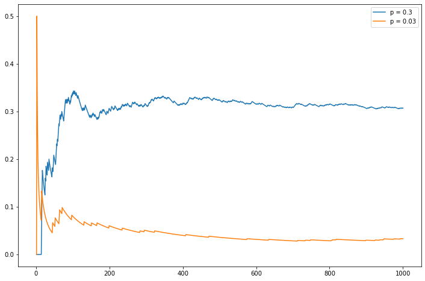

```python
import matplotlib.pyplot as plt
%matplotlib inline

nn = np.arange(1, n + 1)

plt.figure(figsize=(12, 8))
plt.plot(nn, np.cumsum(X1) / nn, label='p = 0.3')
plt.plot(nn, np.cumsum(X2) / nn, label='p = 0.03')
plt.legend(loc='upper right')
plt.show()
```

**Exercise 2.10.21 (Computer Experiment)**. Suppose we flip a coin $n$ times and let $p$ denote the probability of heads. Let $X$ be the number of heads. We call $X$ a binomial random variable which is discussed in the next chapter. Intuition suggests that $X$ will be close to $np$. To see if this is true, we can repeat this experiment many times and average the $X$ values. Carry out a simulation and compare the averages of the $X$'s to $np$. Try this for $p = .3$ and $n = 10, 100, 1000$.

```python
import numpy as np

B = 50000

np.random.seed(0)

X1 = np.random.binomial(n=10, p=0.3, size=B)
X2 = np.random.binomial(n=100, p=0.3, size=B)
X3 = np.random.binomial(n=1000, p=0.3, size=B)
```

```python
print('X1 mean: %.3f' % X1.mean())
print('X1 np:   %.3f' % (0.3 * 10))
print()
print('X2 mean: %.3f' % X2.mean())
print('X2 np:   %.3f' % (0.3 * 100))
print()
print('X3 mean: %.3f' % X3.mean())
print('X3 np:   %.3f' % (0.3 * 1000))
```

```
X1 mean: 2.989
X1 np:   3.000

X2 mean: 30.023
X2 np:   30.000

X3 mean: 299.903
X3 np:   300.000
```

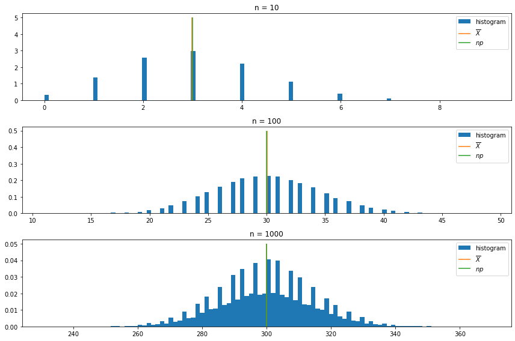

```python
import matplotlib.pyplot as plt
%matplotlib inline

plt.figure(figsize=(12, 8))

ax = plt.subplot(3, 1, 1)
ax.hist(X1, density=True, bins=100, label='histogram', color='C0')
ax.vlines(X1.mean(), ymin=0, ymax=5, label=r'$\overline{X}$', color='C1')
ax.vlines(0.3 * 10, ymin=0, ymax=5, label=r'$np$', color='C2')
ax.legend(loc='upper right')
ax.set_title('n = 10')

ax = plt.subplot(3, 1, 2)
ax.hist(X2, density=True, bins=100, label='histogram', color='C0')
ax.vlines(X2.mean(), ymin=0, ymax=0.5, label=r'$\overline{X}$', color='C1')
ax.vlines(0.3 * 100, ymin=0, ymax=0.5, label=r'$np$', color='C2')
ax.legend(loc='upper right')
ax.set_title('n = 100')

ax = plt.subplot(3, 1, 3)
ax.hist(X3, density=True, bins=100, label='histogram', color='C0')
ax.vlines(X3.mean(), ymin=0, ymax=0.05, label=r'$\overline{X}$', color='C1')
ax.vlines(0.3 * 1000, ymin=0, ymax=0.05, label=r'$np$', color='C2')
ax.legend(loc='upper right')
ax.set_title('n = 1000')

plt.tight_layout()
plt.show()
```

**Exercise 2.10.22 (Computer Experiment)**. Here we will get some experience simulating conditional probabilities. Consider tossing a fair die. Let $A = \{2, 4, 6\}$ and $B = \{1, 2, 3, 4\}$. Then $\mathbb{P}(A) = 1/2$, $\mathbb{P}(B) = 2/3$ and $\mathbb{P}(AB) = 1/3$. Since $\mathbb{P}(AB) = \mathbb{P}(A) \mathbb{P}(B)$, the events $A$ and $B$ are independent. Simulate draws from the sample space and verify that $\hat{P}(AB) = \hat{P}(A) \hat{P}(B)$ where $\hat{P}$ is the proportion of times an event occurred in the simulation. Now find two events $A$ and $B$ that are not independent. Compute $\hat{P}(A)$, $\hat{P}(B)$ and $\hat{P}(AB)$. Compare the calculated values to their theoretical values. Report your results and interpret.

```python
import numpy as np

np.random.seed(0)

B = 10000
results = np.random.randint(low=1, high=7, size=B)
```

```python
A_hat = np.isin(results, [2, 4, 6])
B_hat = np.isin(results, [1, 2, 3, 4])
AB_hat = np.isin(results, [2, 4])
```

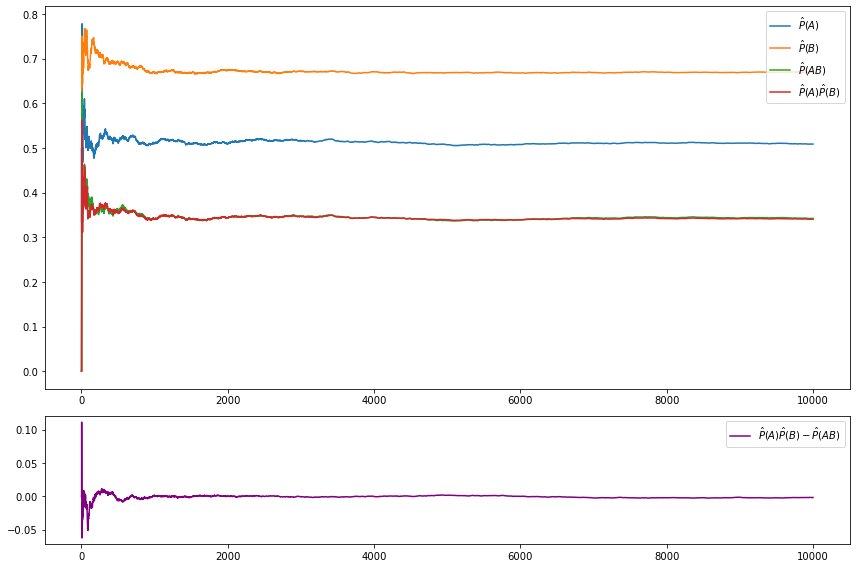

```python
import matplotlib.pyplot as plt
%matplotlib inline

nn = np.arange(1, B + 1)


f, (a0, a1) = plt.subplots(2, 1, gridspec_kw={'height_ratios': [3, 1]}, figsize=(12, 8))

a0.plot(nn, np.cumsum(A_hat) / nn, label=r'$\hat{P}(A)$')
a0.plot(nn, np.cumsum(B_hat) / nn, label=r'$\hat{P}(B)$')
a0.plot(nn, np.cumsum(AB_hat) / nn, label=r'$\hat{P}(AB)$')
a0.plot(nn, np.cumsum(A_hat) * np.cumsum(B_hat) / (nn * nn), label=r'$\hat{P}(A) \hat{P}(B)$')
a0.legend(loc='upper right')

a1.plot(nn, np.cumsum(A_hat) * np.cumsum(B_hat) / (nn * nn) - np.cumsum(AB_hat) / nn,
         label=r'$\hat{P}(A) \hat{P}(B)- \hat{P}(AB)$', color='purple')
a1.legend(loc='upper right')

plt.tight_layout()
plt.show()
```

For our own choice of non-independent events, let $A = \{ 2, 4, 6\}$ and $B = \{2, 4, 5\}$. Then $\mathbb{P}(A) = \mathbb{P}(B) = 1/2$ but $\mathbb{P}(AB) = 1/3$.

```python
A_hat = np.isin(results, [2, 4, 6])
B_hat = np.isin(results, [2, 4, 5])
AB_hat = np.isin(results, [2, 4])
```

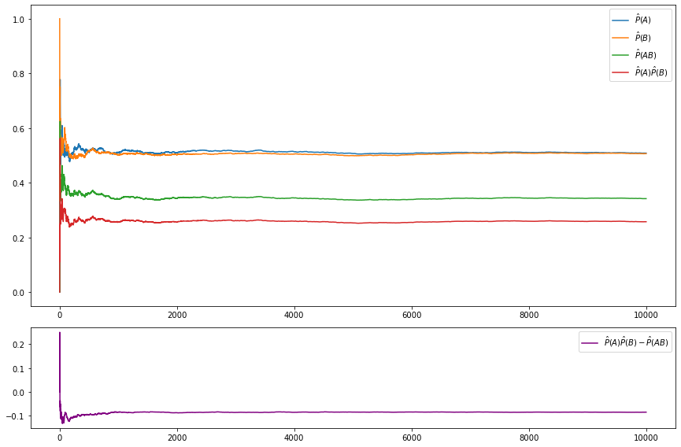

```python
import matplotlib.pyplot as plt
%matplotlib inline

nn = np.arange(1, B + 1)


f, (a0, a1) = plt.subplots(2, 1, gridspec_kw={'height_ratios': [3, 1]}, figsize=(12, 8))

a0.plot(nn, np.cumsum(A_hat) / nn, label=r'$\hat{P}(A)$')
a0.plot(nn, np.cumsum(B_hat) / nn, label=r'$\hat{P}(B)$')
a0.plot(nn, np.cumsum(AB_hat) / nn, label=r'$\hat{P}(AB)$')
a0.plot(nn, np.cumsum(A_hat) * np.cumsum(B_hat) / (nn * nn), label=r'$\hat{P}(A) \hat{P}(B)$')
a0.legend(loc='upper right')

a1.plot(nn, np.cumsum(A_hat) * np.cumsum(B_hat) / (nn * nn) - np.cumsum(AB_hat) / nn,
         label=r'$\hat{P}(A) \hat{P}(B)- \hat{P}(AB)$', color='purple')
a1.legend(loc='upper right')

plt.tight_layout()
plt.show()
```

As noted, the estimates converges to the theoretical value -- and the product of the estimates only converge to the estimate of the joint event in the scenario where the events are independent.